# 第11回 再帰型ニューラルネットワーク（窓切り・時間順分割・隠れ状態・RMSE）

経済データとプログラミングII

第11回

再帰型ニューラルネットワーク

窓で切り、時間の順に試し、順に読む NN と比べる

経済データとプログラミングII

第11回 — Topic01

窓切り

ずらした列を横に並べて、予測する表を作る

## 第11回の道のり

1

窓で切る

実習：実行 データを読む準備

実習：写経 窓切りの表

演習 11-1 窓幅の変更

2

時間順に分ける

実習：写経 時間順の分割

実習：実行 決定係数で比べる準備

実習：実行 くじの番号の変更

3

順に読む

実習：写経 隠れ状態の更新

演習 11-2 持ち越す割合の変更

4

同じ型で比べる

実習：実行 RNN の形の準備

実習：実行 RNN の学びの準備

実習：写経 3 本の比較

いまココ。売上 1 本の記録から、予測する表を作る

## 前の回の振り返り

**前の回**：同じ分け方・同じテストの MSE で、重回帰・Ridge・NN を並べて比べた  
どれも、$X$ と $y$ の表を `fit` に渡して学んだ

**前に出てきた**：アイス店の売上 8 期・`shift` でずらした列・移動平均の窓幅 4（1 年分）

| 期 | 2024 1-3 | 4-6 | 7-9 | 10-12 | 2025 1-3 | 4-6 | 7-9 | 10-12 |
| --- | --- | --- | --- | --- | --- | --- | --- | --- |
| 売上（万円） | 17 | 22 | 26 | 21 | 21 | 26 | 30 | 25 |

このトピックは、このアイス店の 8 期から始める

## このトピックで学ぶこと

- **ここまで**：$X$ と $y$ の表があれば、`fit` に渡して予測できた（重回帰・NN）
- **でも**：店長が「来期の売上を、これまでの売上から見込みたい」  
  予測したいのも手がかりも同じ売上 1 本。$X$ にする列が無い
- **問い**：1 本の記録から、予測する表を作れないか
- **進め方**：前半はアイス店の 8 期、後半で実質 GDP

そこで、前に出てきたずらした列を、横に並べる

## アイス店の売上のずらした列

売上の列を `shift` で下へずらし、1 期前から 4 期前の列を作る（古い列を左に置く）

[figure not shown]

上の 4 行は前の値が足りないので落とす。残る 4 行が予測するための表  
移動平均では窓の 4 期を平均した。今度は平均せず、そのまま横に並べる  
並べておけば、1 期前と 4 期前の効き方を別々に学べる

## ◼ 窓切り

**窓切り：過去の何期分かを横に並べ、次の 1 期を予測する表にする**

定義

$X$過去 $k$ 期の値（$k$：**窓幅**。1 期は 3 か月で、ここでは 4 期＝1 年分）

$y$その直後の 1 期の値

[figure not shown]

窓を 1 期ずつ右へずらすと、8 期から 4 組（8 − 4）。前のページの表の 4 行と同じ

## ◼ 直前値予測

**直前値予測：直前の値をそのまま答える、何も学ばない物差し**

|  | 1 組目 | 2 組目 | 3 組目 | 4 組目 |
| --- | --- | --- | --- | --- |
| 予測（1 期前の列） | 21 | 21 | 26 | 30 |
| 実際（$y$） | 21 | 26 | 30 | 25 |

表の上では、$X$ のいちばん右の列（1 期前）をそのまま答えにするだけ  
予測の良し悪しは、実際と予測の差の大きさで比べる。どの数で測るかは、まだ決めない

学んだ道具がこれに負けるなら、学んだ意味が無い。  
だから、この先いつも並べる

## 実質 GDP の 4 期の窓

今度は実質 GDP（季節調整済）で、同じ手順を  
国内で生み出したモノとサービスの量を、物価の動きを除いて測った数（兆円）

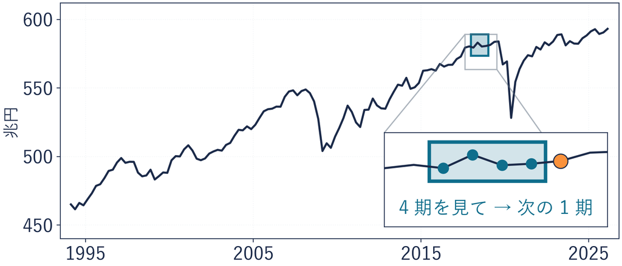

1994 年 1-3 月期から 2026 年 1-3 月期までの 129 期。窓幅 4 は、そう決めた  
値は 3 か月分を 1 年の大きさに直した年率換算。窓幅 4＝4 期＝1 年分とは別の話

## 実質 GDP の窓の表

| 予測する期 | 4 期前 | 3 期前 | 2 期前 | 1 期前 | $y$ |
| --- | --- | --- | --- | --- | --- |
| 1995 年 1-3 月期 | 465.1 | 461.5 | 466.1 | 464.4 | 468.9 |
| 1995 年 4-6 月期 | 461.5 | 466.1 | 464.4 | 468.9 | 473.2 |
| ⋮ | ⋮ | ⋮ | ⋮ | ⋮ | ⋮ |
| 2026 年 1-3 月期 | 591.3 | 592.9 | 589.5 | 590.5 | 593.2 |

単位は兆円。1 行が 1 組（左の 4 列が $X$、右端が $y$）

129 期でも、表は 125 組（129 − 4）  
最初の 4 期（1994 年）は 4 期前が足りないので落ちる。最初の答えは 1995 年 1-3 月期

## データを読む準備のセル

```python
!pip install -q japanize-matplotlib
import japanize_matplotlib
import numpy as np
import pandas as pd
import matplotlib.pyplot as plt
BASE = "ここに manaba の URL を貼る"
gdp = pd.read_csv(BASE + "gdp_real_sa_quarterly.csv", parse_dates=["date"])
tn = gdp.set_index("date").sort_index()["gdp_real_sa"] / 1000
print(len(tn), tn.index[0].date(), tn.index[-1].date())
```

ノートの準備のセル（写さず実行）。先に `BASE` の行の引用符の中を、  
manaba に載せた URL のファイル名の手前（最後の `/` まで）に書き換える  
`tn`：実質 GDP を古い順に並べ、十億円を 1000 で割って兆円にした列  
`129 1994-01-01 2026-01-01` と出る（期の数・最初の期・最後の期）

## 写経 1 窓切りの表

```python
def window(s, k):
    w = pd.DataFrame()
    for lag in range(k, 0, -1):
        w[f"lag{lag}"] = s.shift(lag)
    w["y"] = s
    return w.dropna()
w = window(tn, 4)
print(w.shape)
```

| 行 | 部品 | 渡すもの | できるもの |
| --- | --- | --- | --- |
| 1 | **道具を作る** `def window` | 列 `s`・窓幅 `k` | 窓の表を返す道具 |
| 2-4 | **ずらした列を足す** `shift` | `k` 期前から 1 期前まで | 列の無い表 `w` に `lag4`…`lag1` |
| 5 | **答えの列** | `s` そのまま | 列 `y` |
| 6 | **落とす** `dropna` | 空きのある行 | 空きの無い行だけ |
| 7-8 | **使う・見る** | `tn` が `s` に・4 が `k` に入る | `(125, 5)` |

※ `range(k, 0, -1)` は 4, 3, 2, 1 と数える（古い順に左から並べる）  
※ `f"lag{lag}"` は、数を文字に埋め込んだ列の名前（`lag4` など）

## コードセルの写経と実行

1. **＋ コード**で空のセルを足す  
   （案内の文の下）
2. 写経 1 の 8 行を上から写す
3. **▶** か **Shift + Enter** で実行  
   （Mac は Shift + return）
4. `(125, 5)` を見る  
   （125 組・5 列）

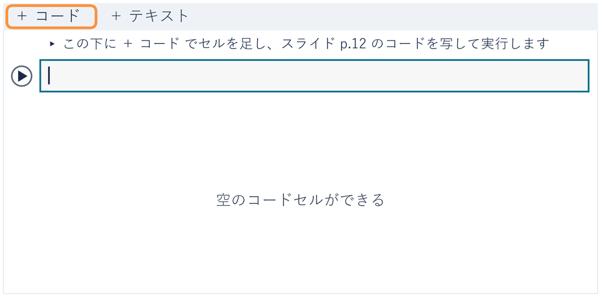

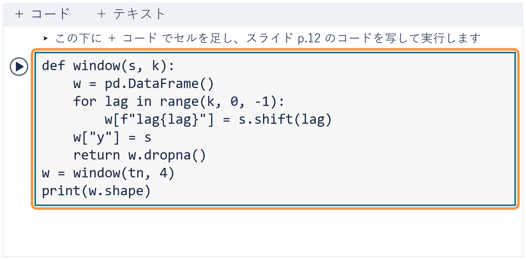

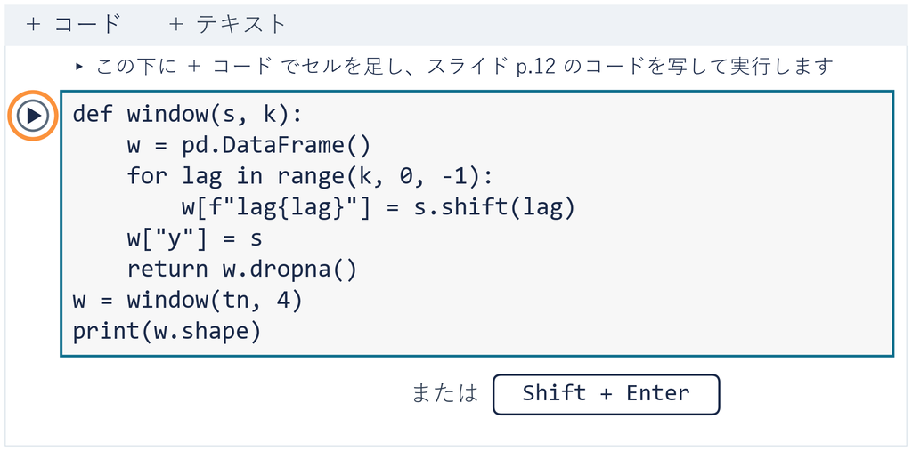

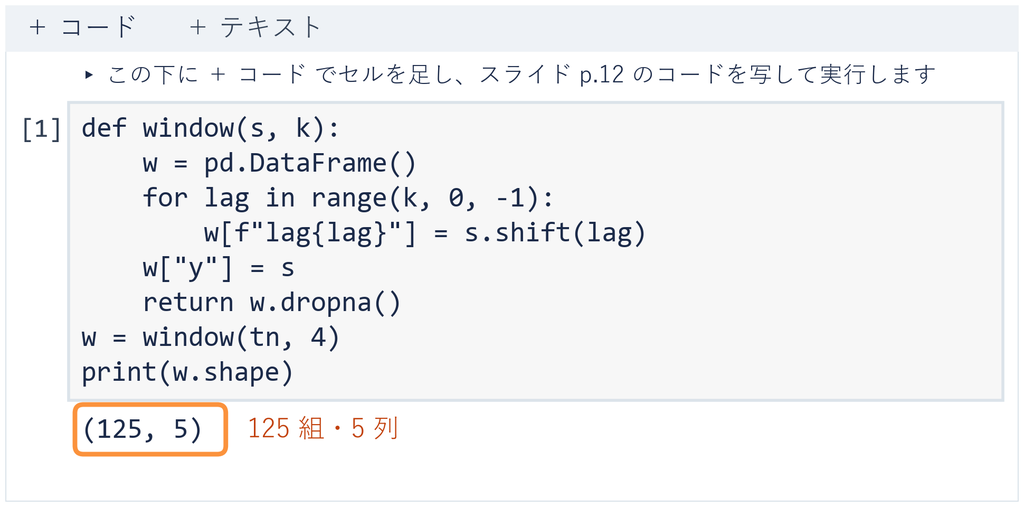

⏸ PAUSE 動画を止めて $2$ 分。`(125, 5)` が出たら再生に戻る

## 演習 11-1 窓幅の変更

演習 11-1

窓幅を 8（2 年分）にすると、表は何組になるか

```python
print(window(tn, 8).shape)
```

1. **先に考える**：窓幅 4 では 125 組。8 では ⓐ 増える ⓑ 同じ ⓒ 減る
2. **写して実行**：上の 1 行を新しいセルで実行（`4` を `8` にしただけ）
3. **終わり**：答え欄に ⓐ〜ⓒ と、出た組の数

⏸ PAUSE 動画を止めて $2$ 分。答えを書いたら再生に戻る

## 演習 11-1 の答え

答えは **ⓒ 減る**。出力は `(121, 9)`（121 組・9 列）

**組の数**：129 − 8 ＝ 121（最初の 8 期は 8 期前が足りない）

**列の数**：8 期前から 1 期前までの 8 列と、$y$ の 1 列で 9 列

**きまり**：欠けが無ければ、$n$ 期・窓幅 $k$ で表は $n - k$ 組

窓を広げるほど、手がかり（$X$ の列）は増え、学ぶ組は減る。  
窓幅は大きければよいわけではない

## まとめ

- 窓切り：過去 $k$ 期を横に並べ、次の 1 期を予測する表にする
- 作り方：`shift` でずらした列を並べ、`dropna` で空きを落とす
- 直前値予測：1 期前をそのまま答える物差し
- 実質 GDP は 129 期・窓幅 4 で 125 組
- この授業の外で：売上・来店数・電気代など 1 本の  
  記録は、まず窓で表にする

ずらした列を並べれば、1 本の記録も予測する表になった  
残った問い ①：この表を、前と同じくくじで分けてよいか（次のトピック）  
残った問い ②：予測と実際の差を、どの数で測るか（最後のトピック）

経済データとプログラミングII

第11回 — Topic02

時間順分割

過去で学び、その後の期間で試す

## 第11回の道のり

1

窓で切る

実習：実行 データを読む準備

実習：写経 窓切りの表

演習 11-1 窓幅の変更

2

時間順に分ける

実習：写経 時間順の分割

実習：実行 決定係数で比べる準備

実習：実行 くじの番号の変更

3

順に読む

実習：写経 隠れ状態の更新

演習 11-2 持ち越す割合の変更

4

同じ型で比べる

実習：実行 RNN の形の準備

実習：実行 RNN の学びの準備

実習：写経 3 本の比較

いまココ。窓の表を、訓練とテストにどう分けるかを見る

## このトピックで学ぶこと

- **ここまで**：窓で切ると、1 本の記録も $X$ と $y$ の表になった
- **でも**：前と同じくくじで分けたくなる  
  前から「月を混ぜた成績は、先の月を当てる評価とは別」と言ってきた
- **問い**：窓の表をくじで分けると、何が起きるか
- **進め方**：前半はアイス店の 4 組、後半で実質 GDP の 125 組

そこで、テストにした組の答えが、ほかの組のどこにあるかを見る

## アイス店の 4 組のくじ分け

4 組から 1 組をくじでテストに。2 組目（答え 26・2025 年 4-6 月）が当たったとする  
組を期の位置に並べた（同じ期の値が縦にそろう）。濃い箱が窓、白い箱が答え

[figure not shown]

答えの 26 が、3 組目と 4 組目の窓の中にある。訓練で、その 26 をもう見ている  
1 組目をテストにすると、答えの 21 は 2・3・4 組目の窓に入る

## ◼ 時間順分割

**時間順分割：過去で学び、その後の期間で試す分け方**

手順

STEP 1時間の順に並べたまま、前を訓練・後ろをテストにする

STEP 2前処理の平均と標準偏差も、訓練の期間だけで決める  
（GDP の平均：全期で約 536 兆円・訓練だけで約 512 兆円。差は約 24 兆円）

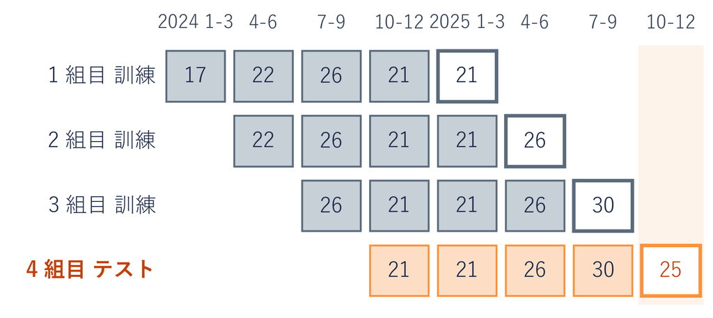

最後の組だけをテストにすると、答えの 25 はどの訓練の窓にも無い。試験はいつも手元より後ろ

残差：実測から予測を引いた差。2020 年からの 25 期の外れの大きさ（残差の平均的な大きさ）は  
未来の期が入るくじの訓練（25 期のうち 14 期）は約 10.2 兆円、過去だけは約 11.4 兆円

## ✋ たしかめ 分け方と決定係数

たしかめ

今度は実質 GDP の 125 組で。テストの $R^2$ が高く出るのは

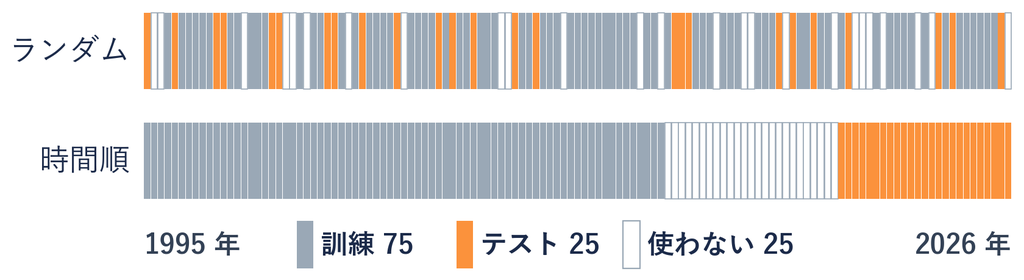

条件：同じ窓（4 期）・同じ線形回帰・訓練 75 組・テスト 25 組。違うのは分け方だけ  
（残り 25 組は、あとで使う検証の分）

**ⓐ** ランダムに分ける **ⓑ** 時間順に分ける **ⓒ** どちらも同じ

⏸ PAUSE 動画を止めて $1$ 分。選んだら再生に戻る

## ★ ランダム分割と時間順分割の決定係数

たしかめの答えは **ⓐ ランダム**

[figure not shown]

同じ窓・同じ線形回帰で、ランダム 0.92・時間順 0.34  
$R^2$ は、外れの大きさを、テストの答えの散らばりと比べた数。  
2 つはテストの期が違うので、数の比は予測力の倍率ではない

## ★ 直前値予測の決定係数

**時間順分割：未来を予測する力は、未来でしか測れない**

[figure not shown]

**ランダム**：直前値をそのまま答えるだけでも 0.92  
テストは 32 年のあちこちで、答えの散らばりは約 37 兆円（標準偏差）

**時間順**：テストは 2020 年 1-3 月期から 2026 年 1-3 月期  
コロナの落ち込みを含む本物の未来で、散らばりは約 14 兆円

0.92 の主な理由は、未来の期が訓練に入ったことではない（外れの大きさの差は約 1 兆円）  
散らばりの大きいテストでは、だいたいの高さ（何百兆円台か）が分かるだけで高い $R^2$ が出る

## よくある失敗 ランダム分割の公平さ

✕ くじで分けるほうが公平。前もそうした

前の回までは、くじで分けて正しかった。だからこの表も、くじで分けたくなる

[figure not shown]

くじの番号を 200 通り変えても、全部 0.84 以上。0.34 を下回るのは 0 通り  
運ではなく分け方の性質。前から言っていた「先の月を当てる評価とは別」は、この差

## ◼ 時系列の分け方の作法

作法

時間順時系列は時間の順に分ける。テストはいちばん後ろ

前処理平均と標準偏差は、訓練の期間だけで決める

物差し直前値予測と並べ、勝ってから「よく予測できた」と言う  
（時間順では、線形回帰 0.34 も直前値 0.43 に届かない）

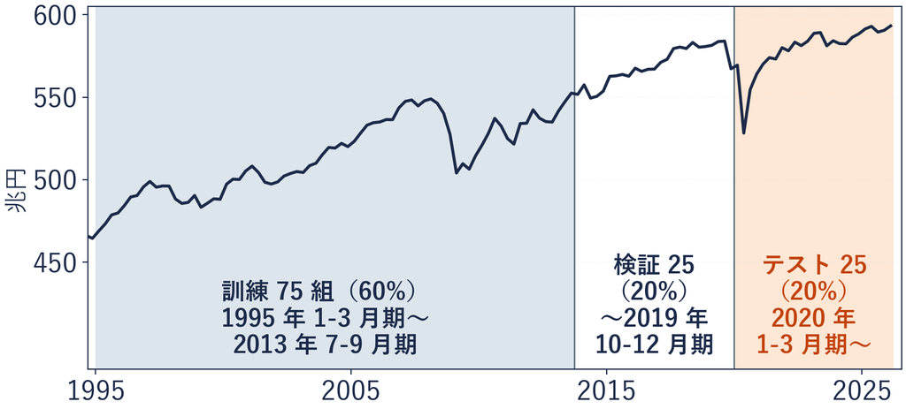

60％・20％・20％は、そう決めた（期末レポートも同じ）  
検証の 25 組は、前に出てきた早期終了の見張り役。次のトピックの RNN で使う

## デモ：分け方の実験室

条件

同じ窓（過去 4 期 → 次の 1 期）・同じ線形回帰で、  
訓練とテストへの割り当てだけを変える。どちらも訓練 75 組・テスト 25 組  
（残り 25 組は検証の分で、ここでは使わない）

- **何を見るか**：テストに選ばれた期（1 組の答えの期を 1 つの印で表す）  
  が 32 年のどこに置かれるか。$R^2$ はどう変わるか
- **図の意味**：線は実質 GDP（季節調整済・兆円）。灰の点が訓練、橙の点がテスト。  
  右に線形の $R^2$ と直前値予測の $R^2$
- **操作**：「ランダム」と「時間順」のボタン、戻す（「開始点」のタブはトピック 4 で使う）

ミッション 予想してから「時間順」を押す。テストに選ばれた期（橙の印）  
がどこへ動き、R² がどう変わるかを手元に書く

※ 次のスライドへ進むときは、デモの枠の外を一度クリックしてから ← → キーを押す

[interactive chart not shown]

## 写経 2 時間順の分割

```python
X, y = w.drop(columns="y"), w["y"]
n = len(y)
train_end, val_end = int(n * 0.6), int(n * 0.8)
Xtr, ytr = X[:train_end], y[:train_end]
Xva, yva = X[train_end:val_end], y[train_end:val_end]
Xte, yte = X[val_end:], y[val_end:]
v = tn[:ytr.index[-1]].to_numpy()
mu, sd = v.mean(), v.std()
print(len(ytr), len(yva), len(yte), yte.index[0].date())
```

| 行 | 部品 | 渡すもの | できるもの |
| --- | --- | --- | --- |
| 1 | **分ける前** | 窓の表 `w` | `X`（4 列）と `y` |
| 2-3 | **境を決める** | 組の数の 6 割・8 割 | `train_end`・`val_end` |
| 4-6 | **前から切る** `[:]` | 境の番号 | 訓練・検証・テスト |
| 7-8 | **前処理の物差し** | `tn`（GDP の列）の頭 79 期 | `mu`・`sd`（次の RNN で使う） |
| 9 | **見る** | 組の数・テストの最初の期 | `75 25 25 2020-01-01` |

※ `X[:train_end]` は前から `train_end` 個。くじは使わない

## コードセルの写経と実行

1. **＋ コード**で空のセルを足す  
   （案内の文の下）
2. 写経 2 の 9 行を上  
   から写す
3. **▶** か **Shift + Enter** で実行  
   （Mac は Shift + return）

4. ```
   75 25 25
   2020-01-01
   ```

   を見る

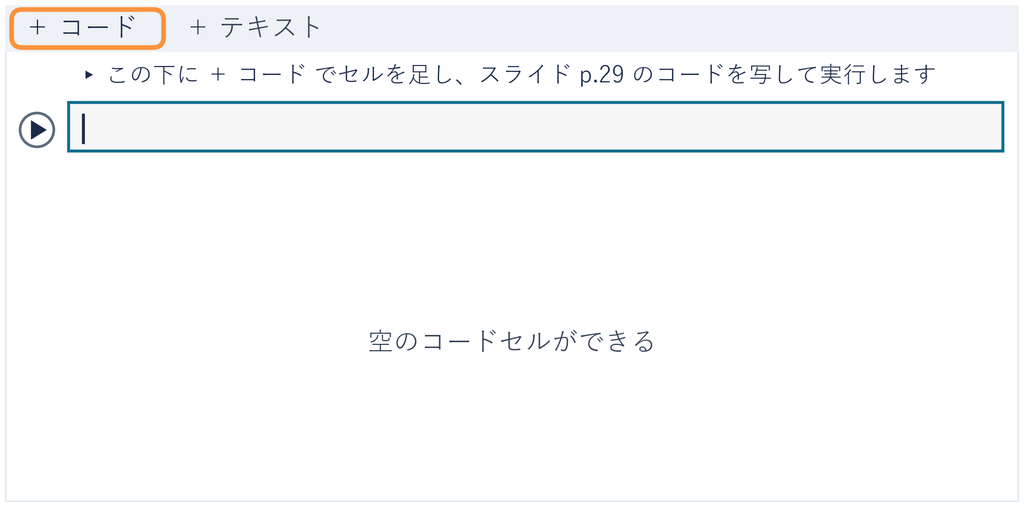

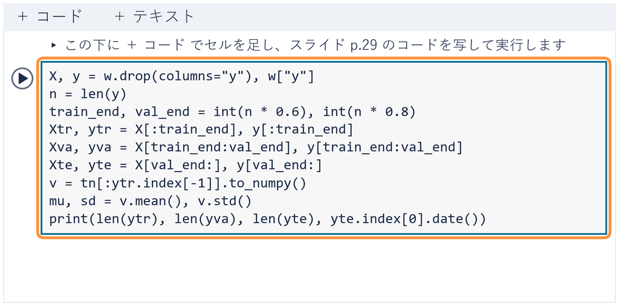

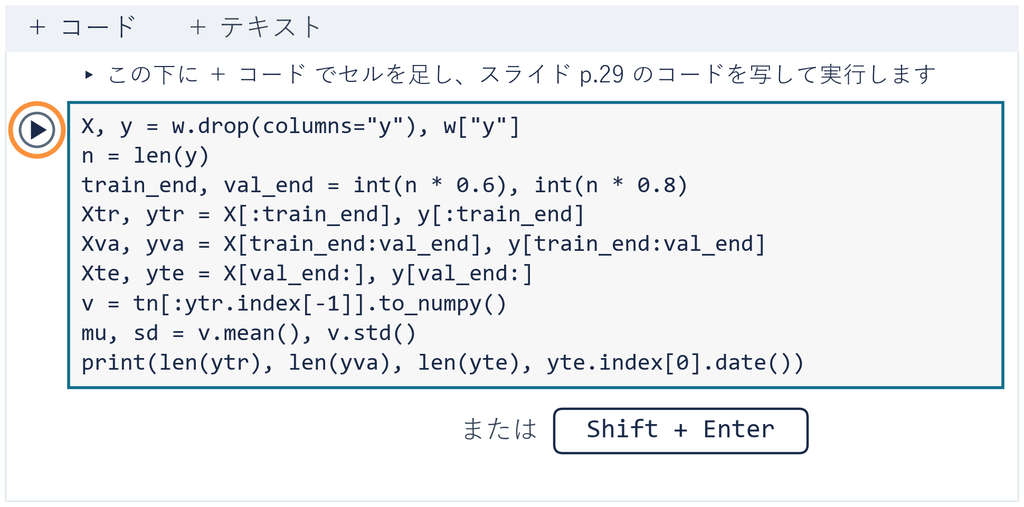

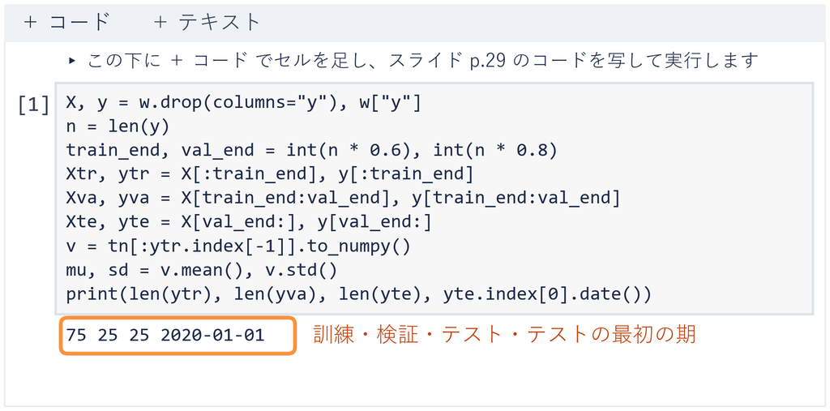

⏸ PAUSE 動画を止めて $2$ 分。`75 25 25 2020-01-01` が出たら再生に戻る

## 決定係数で比べる準備のセル

```python
from sklearn.linear_model import LinearRegression
from sklearn.model_selection import train_test_split
from sklearn.metrics import r2_score, mean_squared_error
def r2_of(Xa, ya, Xb, yb):
    lin = LinearRegression().fit(Xa, ya)
    return round(r2_score(yb, lin.predict(Xb)), 2)
print(r2_of(Xtr, ytr, Xte, yte), round(r2_score(yte, Xte["lag1"]), 2))
```

ノートの準備のセル（写さず実行）。`train_test_split` は次のページ  
`mean_squared_error` は後のトピックで使う  
`r2_of`：訓練で線形回帰を学び、テストの $R^2$ を返す  
`Xte["lag1"]`（1 期前の列）は直前値予測  
`0.34 0.43` と出る（時間順の線形回帰と直前値予測）

## くじの番号を変える実行のセル

ノートの実行のセル（写さず実行）。くじの番号を 42 にしてランダムに分ける

```python
Xa, Xb, ya, yb = train_test_split(X, y, train_size=len(ytr),
                                  test_size=len(yte), random_state=42)
print(r2_of(Xa, ya, Xb, yb), round(r2_score(yb, Xb["lag1"]), 2))
```

1. **確かめる数**：ランダムに分けたときの、線形と直前値の $R^2$
2. **実行する**：先に準備のセルを実行してから、  
   ノートの実行のセルを選んで ▶（写さない）
3. **確かめる**：出た 2 つの数を見比べる

`random_state=42` の 42 はくじの番号。番号そのものに特別な意味は無い

⏸ PAUSE 動画を止めて $1$ 分。実行して 2 つの数を見たら再生に戻る

## くじの番号と決定係数

2 つの数は **ほぼ同じ**。くじ 42 なら `0.92 0.92`

**200 通り**：0〜199 のどの番号でも、線形と直前値の差は 0.07 以内

**読み取り**：何も学ばない直前値でも同じくらい高い $R^2$ が出る。分け方の性質

**この授業の外で**：AI に予測のコードを頼むと、くじで分けたコードが返ることがある  
高い $R^2$ を見たら、まず分け方を疑う

## まとめ

- 時間順分割：過去で学び、その後の期間で試す
- くじで分けると、テストの期の前後が訓練に入る
- 実質 GDP の線形回帰：ランダム 0.92・時間順 0.34  
  直前値予測でもランダムなら 0.92
- くじで分けた高い $R^2$ は、未来を予測する力を測っていなかった

時間順分割：未来を予測する力は、未来でしか測れない  
残った問い：時間順では、線形回帰も直前値予測に届かない  
中身を、順に読む NN に替えられないか。これを次のトピックで見る

経済データとプログラミングII

第11回 — Topic03

再帰型ニューラル  
ネットワーク（RNN）

1 期ずつ読み、要約を持ち越す

## 第11回の道のり

1

窓で切る

実習：実行 データを読む準備

実習：写経 窓切りの表

演習 11-1 窓幅の変更

2

時間順に分ける

実習：写経 時間順の分割

実習：実行 決定係数で比べる準備

実習：実行 くじの番号の変更

3

順に読む

実習：写経 隠れ状態の更新

演習 11-2 持ち越す割合の変更

4

同じ型で比べる

実習：実行 RNN の形の準備

実習：実行 RNN の学びの準備

実習：写経 3 本の比較

いまココ。1 期ずつ読み、メモ（要約）  
を持ち越す NN の仕組みを、小さな数で見る

## このトピックで学ぶこと

- **ここまで**：窓の表なら、重回帰で予測できる（前のトピック）
- **でも**：重回帰は 1 期前・2 期前…の重みを、別々に決めるだけ  
  「近い期ほど効く」という時系列らしい形は使っていない
- **問い**：人のように 1 期ずつ読み、頭の中のメモを書き換えながら進めないか
- **進め方**：このトピックは小さな数  
  （ある店の 4 期の売上 4・2・6・4 万円）だけで仕組みを見る  
  実質 GDP で動かすのは、次のトピック

そこで、メモを次の期へ持ち越す NN を作る  
（**RNN**：再帰型ニューラルネットワーク）

## 重回帰が学んだ 4 つの重み

[figure not shown]

効くのは直前の期（1 期前の 1.20 がほぼ全部）  
でも、ほかの 3 つも 0 ではない。昔がまったく効かないとも言い切れない

**経済**：今年の景気は、去年に強く影響される。何年も前は、そこまでではない

**文章**：次の語は、基本は近くの語で決まる。ずっと前の語が効くこともある

## さかのぼるごとに半分の重み

[figure not shown]

だから、昔の期ほど重みを落としていくのが自然  
「1 期さかのぼるごとに、同じ割合で薄める」とそう決める  
1 期前がいちばん重いのは重回帰と同じ

## 1 期ずつ読むと（展開図）

半分ずつの重みを、1 期ずつ読みながら計算する  
手順は「前のメモを半分にして、今期の値を足す」だけ

[figure not shown]

**展開図**：同じ箱を、読む期の数だけ横に並べた図

## ★ 展開図の数の流れ

[figure not shown]

**隠れ状態：前の期のメモを薄めて、今期の値を書き足した数**

## メモの中身

[figure not shown]

古い値ほど半分ずつ薄まりながら、メモの中に残る  
開くと、重み 1・0.5・0.25・0.125 の足し算。半分ずつの重みと同じ

## ★ h の有無による違い

[figure not shown]

h が無いと、それまでの流れを見ずに  
今期の値だけで答える

## 店 A と店 B のメモ

[figure not shown]

h があるから、今期が同じでも、それまでの流れで答えが変わる

## よくある失敗 時刻ごとの別のニューロン

[figure not shown]

4 つの箱は、同じ 1 個のニューロンを 4 回使ったもの  
同じ箱を使い回すので、窓を広げても決める数は増えない

## ◼ RNN の式

[figure not shown]

定義

$$h_t = f(W_x x_t + W_h h_{t-1} + b)$$

ことばの式：今期のメモ ＝ 押し込み（今期の値 × 重み ＋ 前のメモ × 重み ＋ 切片）

いままでの例は $W_h = 0.5$・$W_x = 1$・$b = 0$・押し込みなし  
割合が 1 を超えると読むほど膨らむ（1.2 なら 4 → 6.8 → 14.16 → 約 21）。だから −1〜1 に押し込む

## 写経 3 隠れ状態の更新

```python
h = 0
for x in [4, 2, 6, 4]:
    h = 0.5 * h + x
    print(round(h, 2))
```

| 行 | 部品 | 渡すもの | できるもの |
| --- | --- | --- | --- |
| 1 | **最初のメモ** | 0（まだ何も読んでいない） | `h` |
| 2 | **1 期ずつ読む** `for` | 4・2・6・4 を順に | 今期の値 `x` |
| 3 | **持ち越して足す** | 前の `h` の半分と `x` | 新しい `h` |
| 4 | **見る** | 小数 2 桁に丸める | `4.0` `4.0` `8.0` `8.0` |

※ 3 行目は、展開図の箱の手順  
「前のメモの半分 ＋ 今期の値」をそのまま書いた 1 行

## コードセルの写経と実行

1. **＋ コード**で空のセルを足す  
   （案内の文の下）
2. 写経 3 の 4 行を上  
   から写す
3. **▶** か **Shift + Enter** で実行  
   （Mac は Shift + return）
4. `4.0` `4.0` `8.0` `8.0` を見る

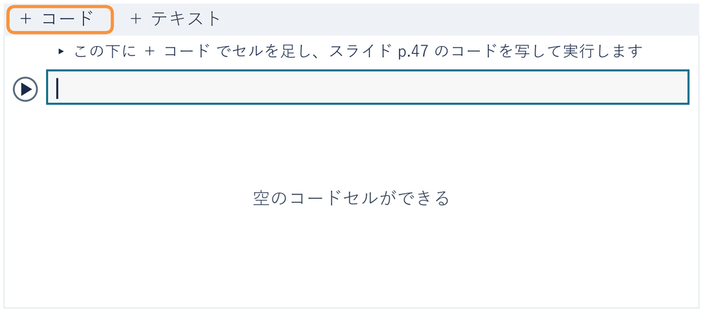

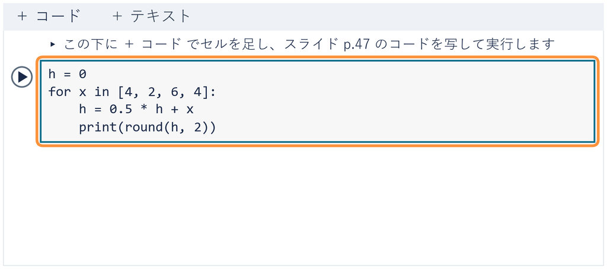

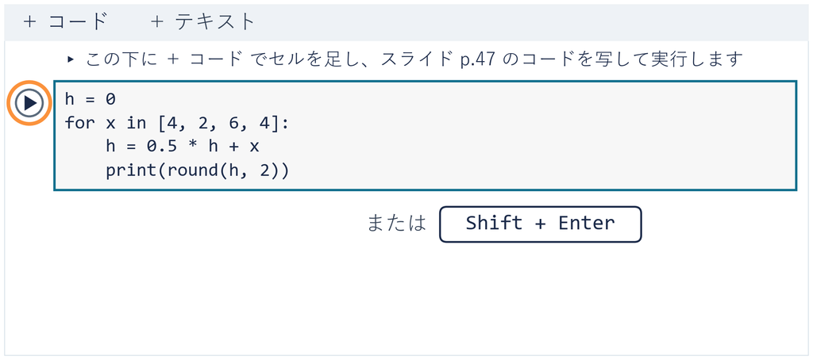

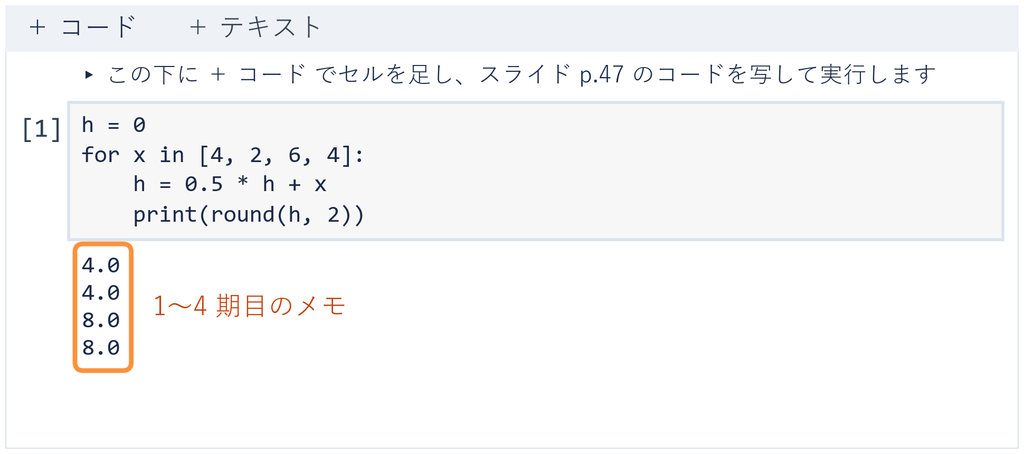

⏸ PAUSE 動画を止めて $2$ 分。`8.0` が 2 回出たら再生に戻る

## 演習 11-2 持ち越す割合の変更

演習 11-2

持ち越す割合を 0.5 から 0.9 にすると、4 期目のメモはどうなるか

```python
h = 0
for x in [4, 2, 6, 4]:
    h = 0.9 * h + x
    print(round(h, 2))
```

1. **先に考える**：0.5 では 8。0.9 では ⓐ 8 より小さい ⓑ 8 のまま ⓒ 8 より大きい
2. **写して変える**：写経 3 の 4 行を新しいセルに写し、3 行目の `0.5` を `0.9` に
3. **終わり**：答え欄に ⓐ〜ⓒ と、出た 4 つの数

⏸ PAUSE 動画を止めて $2$ 分。答えを書いたら再生に戻る

## 演習 11-2 の答え

答えは **ⓒ 8 より大きい**。出力は `4.0`・`5.6`・`11.04`・`13.94`

[figure not shown]

**最初の 4 の残り**：4 × 0.9 × 0.9 × 0.9 ≈ 2.92（0.5 では 0.5）

**読み取り**：持ち越す割合が大きいほど、昔の値がメモの中に長く残る

## 掛け続けた持ち越しの残り

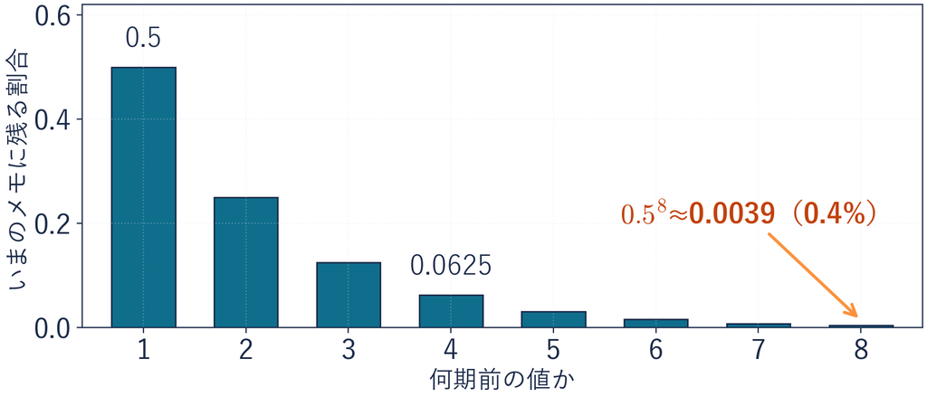

0.5 を掛け続けると、8 期前（2 年前）の値は 0.4% しか残らない

**遠い昔が効く例**：リーマンショック（2008 年）の景気への影響は、何年も残った

**文章でも**：「駅前にできた、評判の、小さなパン屋」は、離れた語が名詞を飾る

**学ぶ信号も薄まる**：遠い昔の値から届く、重みを直す信号も、掛け算で小さくなる（**勾配消失**）

この弱点（遠い昔が薄まる）を補う仕組みは、次のトピックの最後に紹介する

## まとめ

- 隠れ状態：前の期のメモを薄めて、今期の値を書き足した数
- RNN：同じ箱で 1 期ずつ読み、メモを次の期へ持ち越す NN
- 窓を広げても、決める数は増えない（同じ箱の使い回し）
- 今期が同じでも、それまでの流れでメモが変わる
- 使える場面：言葉の並びにも同じ考えが使える。その先に、  
  遠い昔を直接見に行く仕組みもある

1 期ずつ読み、メモを持ち越す仕組みができた  
残った問い：実質 GDP で、  
線形回帰・直前値予測より本当に良く予測できるか。これを次のトピックで見る

経済データとプログラミングII

第11回 — Topic04

RNN による時系列予測

線形・直前値と同じ型で比べる

## 第11回の道のり

1

窓で切る

実習：実行 データを読む準備

実習：写経 窓切りの表

演習 11-1 窓幅の変更

2

時間順に分ける

実習：写経 時間順の分割

実習：実行 決定係数で比べる準備

実習：実行 くじの番号の変更

3

順に読む

実習：写経 隠れ状態の更新

演習 11-2 持ち越す割合の変更

4

同じ型で比べる

実習：実行 RNN の形の準備

実習：実行 RNN の学びの準備

実習：写経 3 本の比較

いまココ。実質 GDP で RNN を動かし、  
3 本の予測を同じ型・同じ物差しで比べる

## このトピックで学ぶこと

- **ここまで**：RNN の仕組みを小さな数で見た  
  型（窓 4・時間順・訓練の期間だけの前処理）もそろっている
- **でも**：実質 GDP で、  
  線形回帰・直前値予測より良く予測できるかは、まだ分からない  
  しかも $R^2$ では、何兆円ずれるかが分からない
- **問い**：3 本を、元の単位のずれで並べられないか
- **進め方**：前半はアイス店の直前値予測で物差しを作る。  
  後半で実質 GDP に RNN を当て、テスト 25 期で比べる

そこで、MSE の平方根をとる（**RMSE**）

## アイス店の直前値予測の残差

窓の表の 4 組で、直前値予測（1 期前）と実際の売上を並べる

[figure not shown]

残差（実際 − 予測）は 0・+5・+4・−5 万円。このずれを 1 つの数にまとめたい

## ◼ RMSE

**RMSE：MSE の平方根で、ずれを元の単位に戻した数**

定義

$$\text{RMSE} = \sqrt{\text{MSE}}$$

MSE：残差の二乗の平均（前に出てきた）。二乗で符号が消え、大きなずれほど重く効く

$\text{MSE}$

$= (0^2 + 5^2 + 4^2 + (-5)^2) \div 4$

残差を二乗して平均

$= (0 + 25 + 16 + 25) \div 4 = 16.5$

単位は万円の二乗

$\text{RMSE} = \sqrt{16.5} \approx 4.06$（万円）。外れの大きさ：RMSE（小さいほど良い）  
ずれの大きさの単純な平均 3.5 万円より少し大きい（大きく外した期を見逃さないため）

## 実質 GDP の窓を読む RNN

[figure not shown]

訓練の最後の窓（答えは 2013 年 7-9 月期）を読む  
メモは 8 個の数（−1〜1）で、期ごとに塗り替わる

## RNN の形の準備のセル

```python
import torch
import torch.nn as nn
class GDPNet(nn.Module):
    def __init__(self):
        super().__init__()
        self.rnn = nn.RNN(1, 8, batch_first=True)
        self.head = nn.Linear(8, 1)
    def forward(self, x):
        seq, _ = self.rnn(x)
        return self.head(seq[:, -1, :]).squeeze(-1)
torch.manual_seed(42)
torch.set_num_threads(1)
Xs, ys = ((X - mu) / sd).to_numpy(), ((y - mu) / sd).to_numpy()
Xt = torch.tensor(Xs, dtype=torch.float32).unsqueeze(-1)
yt = torch.tensor(ys, dtype=torch.float32)
print(tuple(Xt.shape))
```

ノートの準備のセル（写さず実行）。`(125, 4, 1)` と出る  
`nn.RNN(1, 8)`：メモは 8 個（前のトピックの手計算は 1 個にした小さな版）  
`head`：8 個のメモを 1 つの予測にする

## RNN の学びの準備のセル

```python
model, loss_fn = GDPNet(), nn.MSELoss()
opt = torch.optim.Adam(model.parameters(), lr=0.01)
best = float("inf")
for epoch in range(300):
    opt.zero_grad()
    loss_fn(model(Xt[:train_end]), yt[:train_end]).backward()
    opt.step()
    with torch.no_grad():
        val = loss_fn(model(Xt[train_end:val_end]), yt[train_end:val_end])
    if val.item() < best:
        best = val.item()
        keep = {k: p.clone() for k, p in model.state_dict().items()}
model.load_state_dict(keep)
with torch.no_grad():
    rnn_pred = model(Xt[val_end:]).numpy() * sd + mu
print(len(rnn_pred))
```

ノートの準備のセル（写さず実行）。訓練で学び、検証の損失が最も小さい回を取っておく  
（前に出てきた早期終了と同じ考え）。テストは最後に 1 回だけ  
`* sd + mu` で兆円に戻す。`25` と出る（テスト 25 期ぶんの予測）

## ✋ たしかめ 3 本の RMSE

たしかめ

実質 GDP のテスト 25 期で。RMSE がいちばん小さいのは

- **テスト**：2020 年 1-3 月期から 2026 年 1-3 月期（時間順のいちばん後ろ）
- **予測のしかた**：毎期、直前 4 期の実測から次の 1 期を予測する
- **そろえたもの**：窓 4・分け方・訓練の期間だけの前処理

**ⓐ** RNN **ⓑ** 線形回帰 **ⓒ** 直前値予測

⏸ PAUSE 動画を止めて $1$ 分。選んだら再生に戻る

## ★ テスト期間の予測と実測

たしかめの答えは **ⓒ 直前値予測**

[figure not shown]

RMSE は直前値予測 10.5・線形回帰 11.4・RNN 21.1 兆円（GDP は平均 約 579 兆円）  
このデータ・この分け方・この設定では、RNN の外れの大きさがいちばん大きい

## よくある失敗 新しい道具への期待

✕ 新しい道具のほうが良く予測できる

わざわざ新しく習ったのだから  
良く予測できそうに見える

○ 同じ型で確かめてから言う

RNN は 21.1 兆円で  
3 本の中で RMSE がいちばん大きい

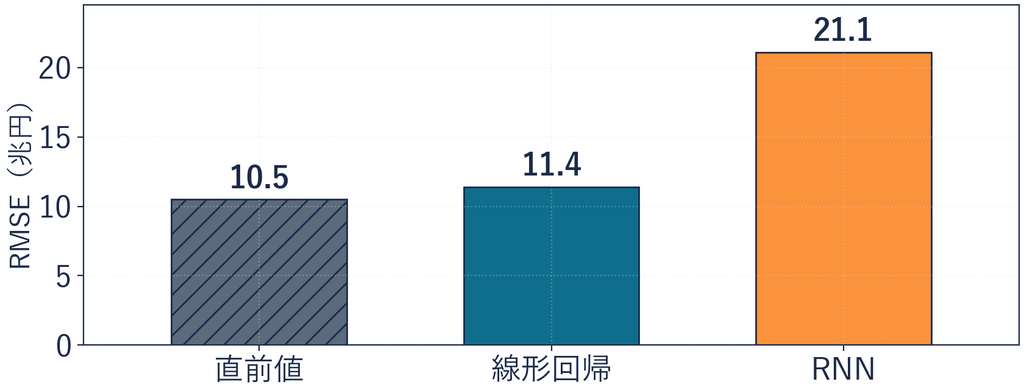

複雑なモデルが勝つとは限らない。比べてから言う

## ★ RNN の予測の頭打ち

[figure not shown]

**見たことのない高さ**：テストの 96%（25 期中 24 期）が、訓練で見た最高 552.5 兆円より上

**頭打ち**：RNN はメモを −1〜1 に押し込むので、出せる高さに上限がある  
上限は理論上 582.9 兆円。今回の予測の最大は 568.7 兆円

**端に張り付くメモ**：テストの窓では、読み終えたメモ 8 個の 26% が端（±0.9 の外）  
訓練の窓では 1% 未満

押し込みは、メモが膨らまないための仕掛け  
その仕掛けが、見たことのない高さに届きにくい大きな理由（と考えられる）

## ★ 直前値予測が一番だった理由

[figure not shown]

結論：直前値予測が一番。GDP は 1 期で平均 0.8% しか動かないので  
（1994〜2026 年）、「前の期とほぼ同じ」がいちばん堅い

**直前値**：外れ（二乗の和）の 86% はコロナの 2 期。3 本とも 25 兆円以上外した  
除くと 4.1 兆円で、1 期の動き（全期の平均 4.2 兆円）とほぼ同じ

**線形回帰**：重みは 1 期前の 1.20 がほぼ全部  
答えは直前値とほとんど同じ（差は平均 2.7 兆円）で、僅差の 2 位

**RNN**：押し込みの設計で出せる高さに上限があり、2021 年以降の 21 期をすべて下に外した

## 写経 4 3 本の比較

```python
lin = LinearRegression().fit(Xtr, ytr)
pred = {"直前値": Xte["lag1"], "線形": lin.predict(Xte),
        "RNN": rnn_pred}
plt.plot(yte.index, yte, color="black", label="実測")
for name, p in pred.items():
    print(name, round(mean_squared_error(yte, p) ** 0.5, 1))
    plt.plot(yte.index, p, label=name)
plt.legend()
plt.show()
```

| 行 | 部品 | 渡すもの | できるもの |
| --- | --- | --- | --- |
| 1 | **線形回帰を学ぶ** `.fit` | 訓練 75 組 | `lin` |
| 2-3 | **3 本の予測** | 1 期前の列・線形回帰・RNN | 名前と予測の組 `pred` |
| 4 | **実測を描く** | テスト 25 期 | 黒の線 |
| 5-7 | **RMSE と線** | `mean_squared_error(…) ** 0.5` | 3 つの RMSE・3 本の線 |
| 8-9 | **見る** | 凡例 | `10.5`・`11.4`・`21.1` と図 |

※ `** 0.5` は平方根（MSE の平方根が RMSE）  
※ このトピックの準備のセル 2 本まで、上から実行しておく

## コードセルの写経と実行

1. **＋ コード**で空のセルを足す  
   （案内の文の下）
2. 写経 4 の 9 行を上  
   から写す
3. **▶** か **Shift + Enter** で実行  
   （Mac は Shift + return）
4. 3 つの RMSE と、  
   テスト期間の図を見る

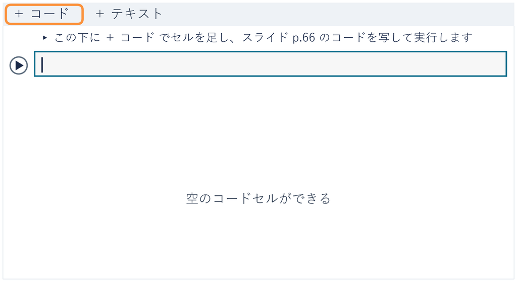

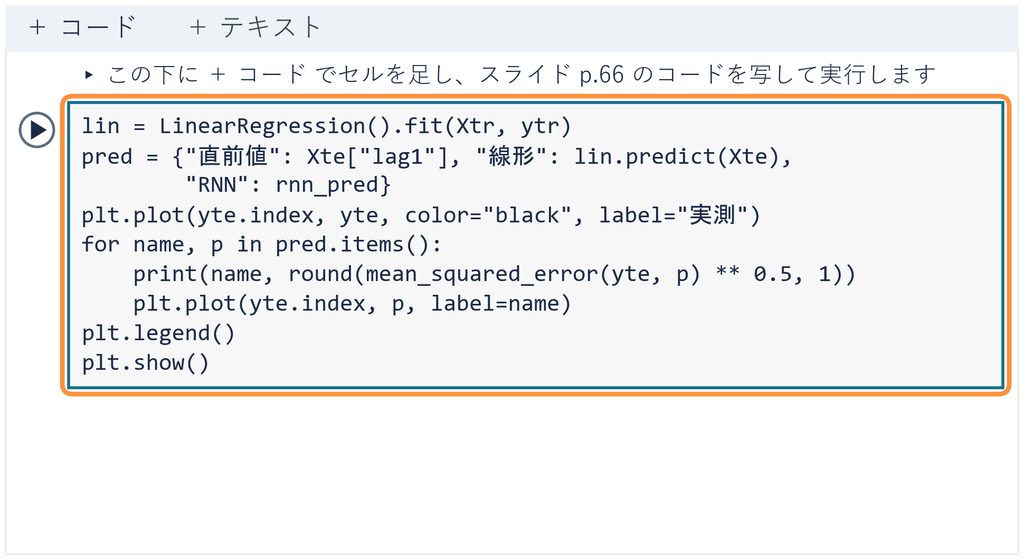

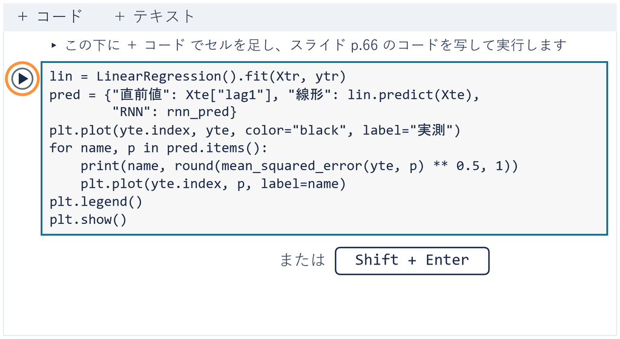

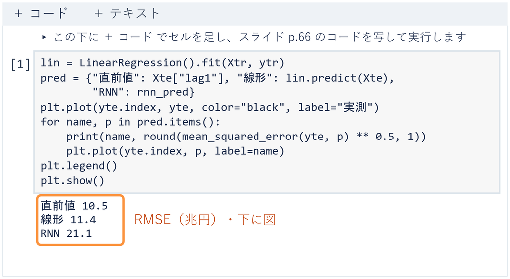

⏸ PAUSE 動画を止めて $2$ 分。3 つの RMSE が出たら再生に戻る

## 第 11 回のまとめ

**窓で切る**：過去の何期分かを横に並べ、次の 1 期を予測する表にする

**時間順に分ける**：過去で学び、その後の期間で試す。くじで分けた高い $R^2$ は、未来を測らない

**順に読む**：RNN はメモ（隠れ状態）を持ち越し、同じ箱で 1 期ずつ読む

**同じ型で比べる**：RMSE で直前値予測 10.5・線形回帰 11.4・RNN 21.1 兆円  
一番は直前値予測（GDP は 1 期でほとんど動かない）

1 本の記録も、窓で切れば、いつもの教師ありで予測できる。ただし試験は時間の順に  
順に読む NN も、同じ型の中で比べて選ぶ

**RNN の改良**：遠い昔が薄まる弱点を補う仲間がある（詳しくは付録 PDF）

**LSTM**：メモとは別に、長く残す通り道（レーン）を持つ  
毎期、門（ゲート）で「残す・忘れる・書き足す」を決める

**GRU**：同じ考えで、門を 2 つ（更新ゲート・リセットゲート）に減らして軽くした形

**実質 GDP では**：LSTM に替えると RMSE 21.1 → 13.8 兆円。それでも直前値予測 10.5 が堅い  
遠い昔が効くデータで、力を出す

いま比べたのは 1 期先予測。予測した値を窓の右端に入れて、また予測する多段予測も付録 PDF に  
いまの 3 本の比べ方が、期末レポートの必須そのもの